# Cálculo de vida útil restante en maquinaria mediante técnicas de Inteligencia Artificial Parte 2

Autor: Iñigo Rekalde Fecha: 28-02-2019

Preparación del entorno

```r
# Fijar el directorio de trabajo
setwd("~/Personal/Master/TFM/R/Def")
# Instalar las librerias si no están instaladas
# install.packages("paquete")
# Cargar librerias
library(dplyr)
library(zoo)
library(ggplot2)
library(reshape2)
library(caret)
```

Preparación para importar

```r
# Los datos a importar no contienen cabeceras.
# Se genera un vector con nombres de las columnas. Train y test comparten columnas.
col_nombres <- c("unit_num","time_cycles","ope_set1","ope_set2","ope_set3",
              "sen1","sen2","sen3","sen4","sen5","sen6","sen7","sen8","sen9","sen10",
              "sen11","sen12","sen13","sen14","sen15","sen16","sen17","sen18","sen19","sen20","sen21")
# Columna de RUL de test
col_RUL <- c("RUL")
# Para facilitar la importación se establecen los tipos de datos por columna.
# Las dos primeras son enteros y las restantes son numericas para train y test
col_tipos <- rep("integer", 2)
col_tipos <- c(col_tipos, rep("numeric", 24))
# RUL como númerica
col_tipo_RUL <- c("numeric")
```

Importación de los ficheros: Datos juego 1 de entrenamiento, test y RUL verdadero Test

```r
# Se importa el fichero para entrenar los modelos en un data frame
dftrain1 <- read.table("train_FD001.txt", col.names = col_nombres, colClasses = col_tipos)
# Se importa el fichero para test o validación en un dataframe
dftest1 <- read.table("test_FD001.txt", col.names = col_nombres, colClasses = col_tipos)
# Se importa el fichero con el RUL de test o validación
dfRUL1 <- read.table("RUL_FD001.txt", col.names = col_RUL, colClasses = col_tipo_RUL)
```

Generar medias y desviación estandar entrenamiento

```r
# Se agregan mas caracterisitcas para ampliar los datos de entrenamiento.
# Por cada uno de las medidas de los 21 sensores se calculan:
# med1 - med21: Media movil para un tamaño de ventana definida
# sd1 - sd21: Desviación estandar para el tamaño de ventana definida
# Tamaño de la ventana para calcular el numero de medidas con las que se calcula
# la media y la desviación estandar
ventana <- 5
# Identificar las columnas iniciales que no son medidas de sensores
columnas_inicio <- 5
# Identificar la o las columnas finales que no son medidas de sensores
columnas_fin <- 1
# NUmero columnas total
columnas_total <- ncol(dftrain1RUL)
# cantidad de sensores
cant_sensores <- columnas_total - columnas_inicio - columnas_fin
# Generar los nombre de las columnas para las medias
columnas_medias <- paste("med",(1:cant_sensores),sep="")
# Generar los nombre de las columnas para las desviaciones estandares
columnas_sd <- paste("sd",(1:cant_sensores),sep="")
# Calcular numero de motores
motores <- unique(dftrain1RUL[,1])
num_motores <- length(motores)
# Generar vector para la media movil
media_movil <- c()
# Generar vector para la desviacion estandar movil
sd_movil <- c()
# Bucle para cada motor
for(i in 1:num_motores){

  # Sub conjunto de datos del motor que estemos analizando en cada ciclo del bucle
  sensoresxmotor = subset(dftrain1RUL[,(columnas_inicio+1):(columnas_total-columnas_fin)],dftrain1RUL$unit_num==motores[i])

  # generar la media movil para todos los sensores
  media_movil = rbind(media_movil,rollapply(sensoresxmotor,ventana,mean,align = "right",partial=1))

  # generar la desviación estandar movil para todos los sensores
  sd_movil_i = rollapply(sensoresxmotor,ventana,sd,align = "right",partial=1)
  sd_movil_i[is.na(sd_movil_i)]=0
  sd_movil = rbind(sd_movil,sd_movil_i)

}
# Convertir las matrices en dataframes
df_media <- as.data.frame(media_movil)
df_sd <- as.data.frame(sd_movil)
# Cambiar los nombres de las columnas
names(df_sd) <- columnas_sd
names(df_media) <- columnas_medias
# Generar el dataframe con los datos originales mas las que hemos generado.
dftrain1med <- cbind(dftrain1RUL[,1:(columnas_inicio + cant_sensores)], df_media, df_sd)
# RUL <- dftrain1RUL[,(columnas_inicio + cant_sensores +1):columnas_total]
# dftrain1med <- cbind(dftrain1med, RUL )
```

Generar medias y desviación estandar test

```r
# Se agregan mas caracterisitcas para ampliar los datos de test.
# Por cada uno de las medidas de los 21 sensores se calculan:
# med1 - med21: Media movil para un tamaño de ventana definida
# sd1 - sd21: Desviación estandar para el tamaño de ventana definida
# Tamaño de la ventana para calcular el numero de medidas con las que se calcula
# la media y la desviación estandar
ventana <- 5
# Identificar las columnas iniciales que no son medidas de sensores
columnas_inicio <- 5
# Identificar la o las columnas finales que no son medidas de sensores
columnas_fin <- 0
# NUmero columnas total
columnas_total <- ncol(dftest1)
# cantidad de sensores
cant_sensores <- columnas_total - columnas_inicio - columnas_fin
# Generar los nombre de las columnas para las medias
columnas_medias <- paste("med",(1:cant_sensores),sep="")
# Generar los nombre de las columnas para las desviaciones estandares
columnas_sd <- paste("sd",(1:cant_sensores),sep="")
# Calcular numero de motores
motores <- unique(dftest1[,1])
num_motores <- length(motores)
# Generar vector para la media movil
media_movil <- c()
# Generar vector para la desviacion estandar movil
sd_movil <- c()
# Bucle para cada motor
for(i in 1:num_motores){

  # Sub conjunto de datos del motor que estemos analizando en cada ciclo del bucle
  sensoresxmotor = subset(dftest1[,(columnas_inicio+1):(columnas_total-columnas_fin)],dftest1$unit_num==motores[i])

  # generar la media movil para todos los sensores
  media_movil = rbind(media_movil,rollapply(sensoresxmotor,ventana,mean,align = "right",partial=1))

  # generar la desviación estandar movil para todos los sensores
  sd_movil_i = rollapply(sensoresxmotor,ventana,sd,align = "right",partial=1)
  sd_movil_i[is.na(sd_movil_i)]=0
  sd_movil = rbind(sd_movil,sd_movil_i)

}
# Convertir las matrices en dataframes
df_media <- as.data.frame(media_movil)
df_sd <- as.data.frame(sd_movil)
# Cambiar los nombres de las columnas
names(df_sd) <- columnas_sd
names(df_media) <- columnas_medias
# Generar el dataframe con los datos originales mas las que hemos generado.
dftest1med <- cbind(dftest1[,1:(columnas_inicio + cant_sensores)], df_media, df_sd)
# RUL <- dftrain1RUL[,(columnas_inicio + cant_sensores +1):columnas_total]
# dftrain1med <- cbind(dftrain1med, RUL )
```

Fichero de Test 1 solo quedarse con el último registro de cada motor

```r
dftest1medult <- merge(aggregate(time_cycles~unit_num, dftest1med,function(x) x[which.max(x)]),dftest1med)
# Ordenarlo por número de motor
dftest1medult <- dftest1medult[with(dftest1medult, order(unit_num)), ]
```

Normalizar Juegos de datos 1

```r
normalizardf1med <- preProcess(dftrain1med, method = "range", rangeBounds = c(0,1))
```

```
No variation for for: ope_set3, sen1, sen5, sen10, sen16, sen18, sen19, med1, med5, med10, med16, med18, med19, sd1, sd5, sd10, sd16, sd18, sd19
```

```r
# No variation for for: ope_set3, sen1, sen5, sen10, sen16, sen18, sen19, med1, med5, med10, med16, med18, med19, sd1, sd5, sd10, sd16, sd18, sd19
dftrain1mednorm <- predict(normalizardf1med, dftrain1med)
```

Eliminar las variables que no varian en el fichero de entrenamiento

```r
dftrain1mednorvar <- dftrain1mednorm[ , -which(names(dftrain1mednorm) %in% c("ope_set3", "sen1", "sen5", "sen10", "sen16", "sen18", "sen19", "med1", "med5", "med10", "med16", "med18", "med19", "sd1", "sd5", "sd10", "sd16", "sd18", "sd19"))]
```

Normalizar el fichero Test

```r
dftest1medultnorm <- predict(normalizardf1med, dftest1medult)
```

Eliminar las variables que no varian en el fichero de Test

```r
dftest1medultnorvar <- dftest1medultnorm[ , -which(names(dftest1medultnorm) %in% c("ope_set3", "sen1", "sen5", "sen10", "sen16", "sen18", "sen19", "med1", "med5", "med10", "med16", "med18", "med19", "sd1", "sd5", "sd10", "sd16", "sd18", "sd19"))]
```

Agregar el Tiempo de vida Util al fichero de entrenamiento

```r
RUL <- dftrain1RUL$RUL
dftrain1mednorvarRUL <- cbind(dftrain1mednorvar, RUL )
```

Prueba 01rfmed Random Forest Medias: - Datos normalizados. - Eliminados datos que no varian. - Juego de datos 1 - Random Forest - Sensores, desviaciones y medias moviles - 1 parametro. - Metodo: oob - Metrica RMSE - Arboles: 8

```r
# Parametros de control
control01med <- trainControl(
  method = "oob")
# Valor para la semilla a la hora de generar numeros aleatorios y que tenga repetitibilidad
set.seed(128)
# Entrenar el modelo
modelo_rf01med = train(RUL ~ ., data=dftrain1mednorvarRUL,
                          method='rf',
                          preProcess=NULL,
                          metric = "RMSE",
                          replace = TRUE,
                          tuneLength = 1,
                          ntree = 8,
                          importance=T,
                          trControl = control01med)
```

Resultados entrenamiento:

```r
print(modelo_rf01med)
```

```
Random Forest

20631 samples
   49 predictor

No pre-processing
Resampling results:

  RMSE      Rsquared
  33.11921  0.768803

Tuning parameter 'mtry' was held constant at a value of 7
```

Muestra la importancia de las variables:

```r
varimp_rf01med <-varImp(modelo_rf01med)
print(varimp_rf01med)
```

```
rf variable importance

  only 20 most important variables shown (out of 49)
```

|  | Overall |
| --- | --- |
| unit_num | 100.00000 |
| med7 | 98.40721 |
| sen14 | 87.95107 |
| time_cycles | 87.04432 |
| med9 | 63.35406 |
| sd14 | 60.25911 |
| sd11 | 58.22336 |
| sd15 | 57.36320 |
| med3 | 51.40348 |
| sd12 | 45.99883 |

[output cut: 10 more lines]

Genera la predicción del tiempo de vida restante sobre los datos de Test

```r
prediccion_rf01med <- predict(modelo_rf01med, newdata = dftest1medultnorvar)
```

Calculo RMSE Test

```r
# Calculo RMSE Test
prediccion_ord <- prediccion_rf01med[order(as.integer(names(prediccion_rf01med)))]
er_test <- (prediccion_ord - dfRUL1$RUL)
RMSE_test_rf01med <- sqrt(mean(er_test^2))
print("RMSE datos Test:")
```

```
[1] "RMSE datos Test:"
```

```r
print(RMSE_test_rf01med)
```

```
[1] 59.5261
```

Prueba (rn01med) Redes Neuronales Media: - Datos normalizados. - Eliminados datos que no varian. - Juego de datos 1 - Redes Neuronales (mxnet) - Sensores, desviaciones y medias moviles. - Parametros por defecto - Metrica RMSE

```r
# Valor para la semilla a la hora de generar numeros aleatorios y que tenga repetitibilidad
set.seed(128)
# Entrenar el modelo
modelo_rn01med <- train(
  x = dftrain1mednorvar,
  y = dftrain1RUL$RUL,
  method = "mxnet",
  preProc =  NULL
  )
```

```
Start training with 1 devices
[1] Train-rmse=127.300763777745
[2] Train-rmse=127.006102856295
[3] Train-rmse=126.714056085657
[4] Train-rmse=126.423677844766
[5] Train-rmse=126.134637243954
[6] Train-rmse=125.846828837454
[7] Train-rmse=125.560174494614
[8] Train-rmse=125.274538063709
[9] Train-rmse=124.989437056176
[10] Train-rmse=124.701970983435
Start training with 1 devices
[1] Train-rmse=126.715367352521
[2] Train-rmse=120.904923568537
[3] Train-rmse=97.0785840352376
```

[output cut: 277 more lines]

Resultados entrenamiento:

```r
print(modelo_rn01med)
```

```
Neural Network

20631 samples
   49 predictor

No pre-processing
Resampling: Bootstrapped (25 reps)
Summary of sample sizes: 20631, 20631, 20631, 20631, 20631, 20631, ...
Resampling results across tuning parameters:

  layer1  dropout  RMSE       Rsquared    MAE
  1       0.00     125.05955  0.04232425  104.47514
  1       0.35     125.05955  0.04232425  104.47514
  1       0.70     125.05955  0.04232425  104.47514
  3       0.00      56.38910  0.55382977   46.24848
  3       0.35      56.38910  0.55382977   46.24848
  3       0.70      56.38910  0.55382977   46.24848
  5       0.00      55.62595  0.56416682   45.54503
  5       0.35      55.62595  0.56416682   45.54503
  5       0.70      55.62595  0.56416682   45.54503

Tuning parameter 'layer2' was held constant at a value of 0
Tuning parameter 'layer3' was held

Tuning parameter 'momentum' was held constant at a value of 0.9
Tuning parameter 'activation' was
 held constant at a value of relu
RMSE was used to select the optimal model using the smallest value.
The final values used for the model were layer1 = 5, layer2 = 0, layer3 = 0, learning.rate =
 2e-06, momentum = 0.9, dropout = 0 and activation = relu.
```

Genera la predicción del tiempo de vida restante sobre los datos de Test

```r
prediccion_rn01med <- predict(modelo_rn01med, newdata = dftest1medultnorvar)
```

Calculo RMSE Test

```r
# Calculo RMSE Test
prediccion_ord <- prediccion_rn01med
er_test <- (prediccion_ord - dfRUL1$RUL)
RMSE_test_rn01med <- sqrt(mean(er_test^2))
print("RMSE datos Test:")
```

```
[1] "RMSE datos Test:"
```

```r
print(RMSE_test_rn01med)
```

```
[1] 40.04431
```

Muestra la importancia de las variables:

```r
varimp_rn01med <-varImp(modelo_rn01med)
print(varimp_rn01med)
```

```
loess r-squared variable importance

  only 20 most important variables shown (out of 49)
```

|  | Overall |
| --- | --- |
| med4 | 100.00000 |
| time_cycles | 98.41786 |
| med11 | 97.36053 |
| med15 | 97.20150 |
| med21 | 97.13665 |
| med3 | 93.95557 |
| med20 | 93.42623 |
| med17 | 93.23666 |
| med12 | 92.36067 |
| med7 | 92.06751 |

[output cut: 10 more lines]

Dejar solo 20 variables en el fichero de entrenamiento

```r
# dftrain1mednorvar20 <- dftrain1mednorvar[ , -which(names(dftest1medultnorm) %in% c("unit_num","ope_set1", "ope_set2", "sen1", "sen3", "sen6", "sen8", "sen9", "sen13", "sen14", "med6", "med8", "med9", "med13", "med14", "sd2", "sd3", "sd4", "sd6","sd7", "sd8", "sd9", "sd11","sd12", "sd13", "sd14", "sd15", "sd17", "sd20", "sd21"))]
dftrain1mednorvar20 <- dftrain1mednorvar[ , which(names(dftest1medultnorm) %in% c("med4","time_cycles", "med11", "med15", "med21", "med3", "med20", "med17", "med12", "med7", "med2", "sen11", "sen4", "sen12", "sen7", "sen21", "sen15", "sen20", "sen2", "sen17"))]
```

Entrenar el modelo

```r
# Valor para la semilla a la hora de generar numeros aleatorios y que tenga repetitibilidad
set.seed(128)
# Entrenar el modelo
modelo_rn01med20 <- train(
  x = dftrain1mednorvar20,
  y = dftrain1RUL$RUL,
  method = "mxnet",
  preProc =  NULL
  )
```

```
Start training with 1 devices
[1] Train-rmse=127.31296374474
[2] Train-rmse=127.006100407353
[3] Train-rmse=126.714046713747
[4] Train-rmse=126.423758848214
[5] Train-rmse=126.134845451072
[6] Train-rmse=125.847197732808
[7] Train-rmse=125.560776981307
[8] Train-rmse=125.275570104152
[9] Train-rmse=124.991564385685
[10] Train-rmse=124.708760014287
Start training with 1 devices
[1] Train-rmse=126.390752863001
[2] Train-rmse=122.975136321268
[3] Train-rmse=113.598950232989
```

[output cut: 2471 more lines]

Resultados entrenamiento:

```r
print(modelo_rn01med20)
```

```
Neural Network

20631 samples
   20 predictor

No pre-processing
Resampling: Bootstrapped (25 reps)
Summary of sample sizes: 20631, 20631, 20631, 20631, 20631, 20631, ...
Resampling results across tuning parameters:

  layer1  dropout  RMSE       Rsquared     MAE
  1       0.00     125.06647  0.001464389  104.48389
  1       0.35     125.06647  0.001464389  104.48389
  1       0.70     125.06647  0.001464389  104.48389
  3       0.00      62.21028  0.477863610   51.07257
  3       0.35      62.21028  0.477863610   51.07257
  3       0.70      62.21028  0.477863610   51.07257
  5       0.00      61.27966  0.512592129   50.23221
  5       0.35      61.27966  0.512592129   50.23221
  5       0.70      61.27966  0.512592129   50.23221

Tuning parameter 'layer2' was held constant at a value of 0
Tuning parameter 'layer3' was held

Tuning parameter 'momentum' was held constant at a value of 0.9
Tuning parameter 'activation' was
 held constant at a value of relu
RMSE was used to select the optimal model using the smallest value.
The final values used for the model were layer1 = 5, layer2 = 0, layer3 = 0, learning.rate =
 2e-06, momentum = 0.9, dropout = 0 and activation = relu.
```

Revisar Dejar solo 20 variables en test

```r
# dftest1medultnorvar20 <- dftest1medultnorvar[ , -which(names(dftest1medultnorm) %in% c("unit_num", "ope_set1", "ope_set2", "sen1", "sen3", "sen6", "sen8", "sen9", "sen13", "sen14", "med6", "med8", "med9", "med13", "med14", "sd2", "sd3", "sd4", "sd6", "sd7", "sd8", "sd9", "sd11", "sd12", "sd13", "sd14", "sd15", "sd17", "sd20", "sd21"))]
dftest1medultnorvar20 <- dftest1medultnorvar[ , which(names(dftest1medultnorm) %in% c("med4","time_cycles", "med11", "med15", "med21", "med3", "med20", "med17", "med12", "med7", "med2", "sen11", "sen4", "sen12", "sen7", "sen21", "sen15", "sen20", "sen2", "sen17"))]
```

Genera la predicción del tiempo de vida restante sobre los datos de Test

```r
prediccion_rn01med20 <- predict(modelo_rn01med20, newdata = dftest1medultnorvar20)
```

Calculo RMSE Test

```r
# Calculo RMSE Test
prediccion_ord <- prediccion_rn01med20
er_test <- (prediccion_ord - dfRUL1$RUL)
RMSE_test_rn01med20 <- sqrt(mean(er_test^2))
print("RMSE datos Test:")
```

```
[1] "RMSE datos Test:"
```

```r
print(RMSE_test_rn01med20)
```

```
[1] 44.63903
```

Muestra la importancia de las variables:

```r
varimp_rn01med20 <-varImp(modelo_rn01med20)
print(varimp_rn01med20)
```

```
loess r-squared variable importance
```

|  | Overall |
| --- | --- |
| med4 | 100.000000 |
| time_cycles | 98.412768 |
| med20 | 93.405078 |
| med12 | 92.336095 |
| med2 | 91.981982 |
| sen11 | 87.972466 |
| sen4 | 83.644029 |
| sen7 | 78.356345 |
| sen15 | 74.909916 |
| sen17 | 66.604035 |

[output cut: 10 more lines]

prueba01med20parametros01

Prueba (rn01med20p01) Redes Neuronales Ajuste parametros - Datos normalizados. - Eliminados datos que no varian. - Juego de datos 1 - Redes Neuronales (mxnet) - Sensores, desviaciones y medias moviles. - Solo los 20 mas relevantes - Parametros ajustados - Metrica RMSE

```r
# Parametros de Ajuste
grid_par01 <- expand.grid(
  layer1 = 5,
  layer2 = 2,
  layer3 = 1,
  learning.rate = 0.000002,
  momentum = 0.9,
  dropout = 0,
  activation = "relu"
  )
# Valor para la semilla a la hora de generar numeros aleatorios y que tenga repetitibilidad
set.seed(128)
# Entrenar el modelo
modelo_rn01med20p01 <- train(
  x = dftrain1mednorvar20,
  y = dftrain1RUL$RUL,
  method = "mxnet",
  preProc =  NULL ,
  tuneGrid = grid_par01
  )
```

```
Start training with 1 devices
[1] Train-rmse=127.268797321084
[2] Train-rmse=126.448748600336
[3] Train-rmse=106.630848425406
[4] Train-rmse=60.3056863149007
[5] Train-rmse=45.9165003505754
[6] Train-rmse=42.3923445807563
[7] Train-rmse=41.4901488739767
[8] Train-rmse=40.7690710609342
[9] Train-rmse=40.1922498514623
[10] Train-rmse=39.7398109436035
Start training with 1 devices
[1] Train-rmse=127.985599800392
[2] Train-rmse=127.145678061026
[3] Train-rmse=106.1483404136
```

[output cut: 271 more lines]

Resultados entrenamiento:

```r
print(modelo_rn01med20p01)
```

[output not shown]

Genera la predicción del tiempo de vida restante sobre los datos de Test

```r
prediccion_rn01med20p01 <- predict(modelo_rn01med20p01, newdata = dftest1medultnorvar20)
```

Calculo RMSE Test

```r
# Calculo RMSE Test
prediccion_ord <- prediccion_rn01med20p01
er_test <- (prediccion_ord - dfRUL1$RUL)
er_test_rn01med20p01 <- er_test
RMSE_test_rn01med20p01 <- sqrt(mean(er_test^2))
print("RMSE datos Test:")
```

```
[1] "RMSE datos Test:"
```

```r
print(RMSE_test_rn01med20p01)
```

```
[1] 31.63334
```

Histograma Error

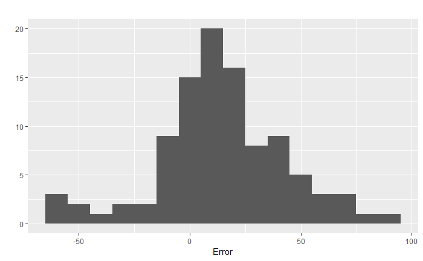

```r
dferp01 <- as.data.frame(er_test_rn01med20p01)
ggplot(data=dferp01, aes(dferp01$er_test_rn01med20p01)) +
  geom_histogram(binwidth = 10)+
  labs(title="", x="Error", y="")
```